# Day - 9, 10 & 11 - Exploratory Data Analytics

Rajeev

Exploratory Data Analysis (EDA) is an approach/philosophy for data analysis that employs a variety of techniques, mostly graphical, to display data in such a way that interesting features will become apparent. We use EDA to get insight into data set, uncover underlying structures in data, extract important variables, detect outliers and anomalies in data, test underlying assumptions about data, develop parsimonious models etc.

In these following modules, first I will demonstrate different kinds of simple graphs that can be useful in exploratory analyses and then I will explain how we can create those graphs using R’s plotting systems. In the end we will also do some case studies.

## Exploratory Graphs

So far we have been using `str()`, `summary()` and `table()` functions to take a look at data and understand what it represents. But you can only understand little about the data using these functions. By creating plots we will be able to know a lot more about the data. In this section we will look into different kinds of simple graphs that can be used in exploratory analyses.

For this section we will be using the inbuilt data set in R, `mtcars`. The data was extracted from the 1974 Motor Trend US magazine, and comprises fuel consumption and 10 aspects of automobile design and performance for 32 automobiles (1973-74 models).

Let’s have a look at the data set.

```r
> str(mtcars)
## 'data.frame':    32 obs. of  11 variables:
##  $ mpg : num  21 21 22.8 21.4 18.7 18.1 14.3 24.4 22.8 19.2 ...
##  $ cyl : num  6 6 4 6 8 6 8 4 4 6 ...
##  $ disp: num  160 160 108 258 360 ...
##  $ hp  : num  110 110 93 110 175 105 245 62 95 123 ...
##  $ drat: num  3.9 3.9 3.85 3.08 3.15 2.76 3.21 3.69 3.92 3.92 ...
##  $ wt  : num  2.62 2.88 2.32 3.21 3.44 ...
##  $ qsec: num  16.5 17 18.6 19.4 17 ...
##  $ vs  : num  0 0 1 1 0 1 0 1 1 1 ...
##  $ am  : num  1 1 1 0 0 0 0 0 0 0 ...
##  $ gear: num  4 4 4 3 3 3 3 4 4 4 ...
##  $ carb: num  4 4 1 1 2 1 4 2 2 4 ...
>
> summary(mtcars)
##       mpg             cyl             disp             hp
##  Min.   :10.40   Min.   :4.000   Min.   : 71.1   Min.   : 52.0
##  1st Qu.:15.43   1st Qu.:4.000   1st Qu.:120.8   1st Qu.: 96.5
##  Median :19.20   Median :6.000   Median :196.3   Median :123.0
##  Mean   :20.09   Mean   :6.188   Mean   :230.7   Mean   :146.7
##  3rd Qu.:22.80   3rd Qu.:8.000   3rd Qu.:326.0   3rd Qu.:180.0
##  Max.   :33.90   Max.   :8.000   Max.   :472.0   Max.   :335.0
##       drat             wt             qsec             vs
##  Min.   :2.760   Min.   :1.513   Min.   :14.50   Min.   :0.0000
##  1st Qu.:3.080   1st Qu.:2.581   1st Qu.:16.89   1st Qu.:0.0000
##  Median :3.695   Median :3.325   Median :17.71   Median :0.0000
##  Mean   :3.597   Mean   :3.217   Mean   :17.85   Mean   :0.4375
##  3rd Qu.:3.920   3rd Qu.:3.610   3rd Qu.:18.90   3rd Qu.:1.0000
##  Max.   :4.930   Max.   :5.424   Max.   :22.90   Max.   :1.0000
##        am              gear            carb
##  Min.   :0.0000   Min.   :3.000   Min.   :1.000
##  1st Qu.:0.0000   1st Qu.:3.000   1st Qu.:2.000
##  Median :0.0000   Median :4.000   Median :2.000
##  Mean   :0.4062   Mean   :3.688   Mean   :2.812
##  3rd Qu.:1.0000   3rd Qu.:4.000   3rd Qu.:4.000
##  Max.   :1.0000   Max.   :5.000   Max.   :8.000
```

Here is a brief description of each variable in data set.

```
mpg     Fuel efficiency in miles/(US) gallon
cyl     Number of cylinders
disp    Displacement (cu.in.)
hp      Gross horsepower
drat    Rear axle ratio
wt      Weight (lb/1000)
qsec    1/4 mile time
vs      V/S
am      Transmission (0 = automatic, 1 = manual)
gear    Number of forward gears
carb    Number of carburetors
```

```r
> head(mtcars)
##                    mpg cyl disp  hp drat    wt  qsec vs am gear carb
## Mazda RX4         21.0   6  160 110 3.90 2.620 16.46  0  1    4    4
## Mazda RX4 Wag     21.0   6  160 110 3.90 2.875 17.02  0  1    4    4
## Datsun 710        22.8   4  108  93 3.85 2.320 18.61  1  1    4    1
## Hornet 4 Drive    21.4   6  258 110 3.08 3.215 19.44  1  0    3    1
## Hornet Sportabout 18.7   8  360 175 3.15 3.440 17.02  0  0    3    2
## Valiant           18.1   6  225 105 2.76 3.460 20.22  1  0    3    1
```

Each line of `mtcars` represents one model of car, which we can see in the row names. Each column is then one attribute of that car, such as the miles per gallon (or fuel efficiency), the number of cylinders, the displacement (or volume) of the car’s engine in cubic inches, whether the car has an automatic or manual transmission, and so on.

## Simple One Dimention plots

We will first look into simple one dimention summaries. When you first take a look at data set you would want to start with these simple summeries to get some insights on the data. There are 6 important kinds of one dimentional summaries.

- Five-number Summary
- Boxplots
- Histograms
- Density plots
- Barplot
- Dot plot

### Five-number Summary

Here, we compute a five-number summary of the fuel efficiency variable `mpg` in mtcars data set. For interactive work, it’s often a bit nice to use the `summary()` function as it give nice headers unlike `fivenum()`.

```r
> fivenum(mtcars$mpg)
## [1] 10.40 15.35 19.20 22.80 33.90
>
> # summary also give one more quantity, mean
> summary(mtcars$mpg)
##    Min. 1st Qu.  Median    Mean 3rd Qu.    Max.
##   10.40   15.42   19.20   20.09   22.80   33.90
```

### Boxplots

Boxplots are a visual representation of the five-number summary plus a bit more information. In particular, boxplots commonly plot outliers that go beyond the bulk of the data.

Here is an image describing barplot integrates five point summery into a graph.

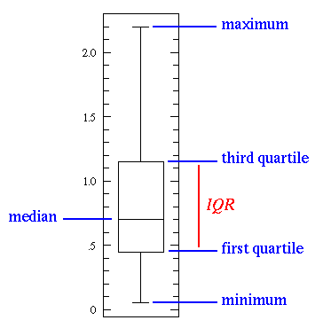

Boxplot is implemented via the `boxplot()` function.

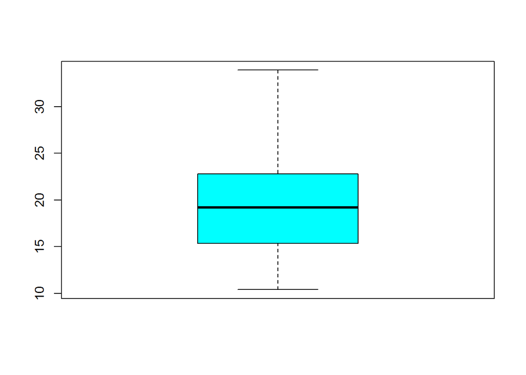

```r
> # the col argument determines the color of box
> boxplot(mtcars$mpg, col = "cyan")
```

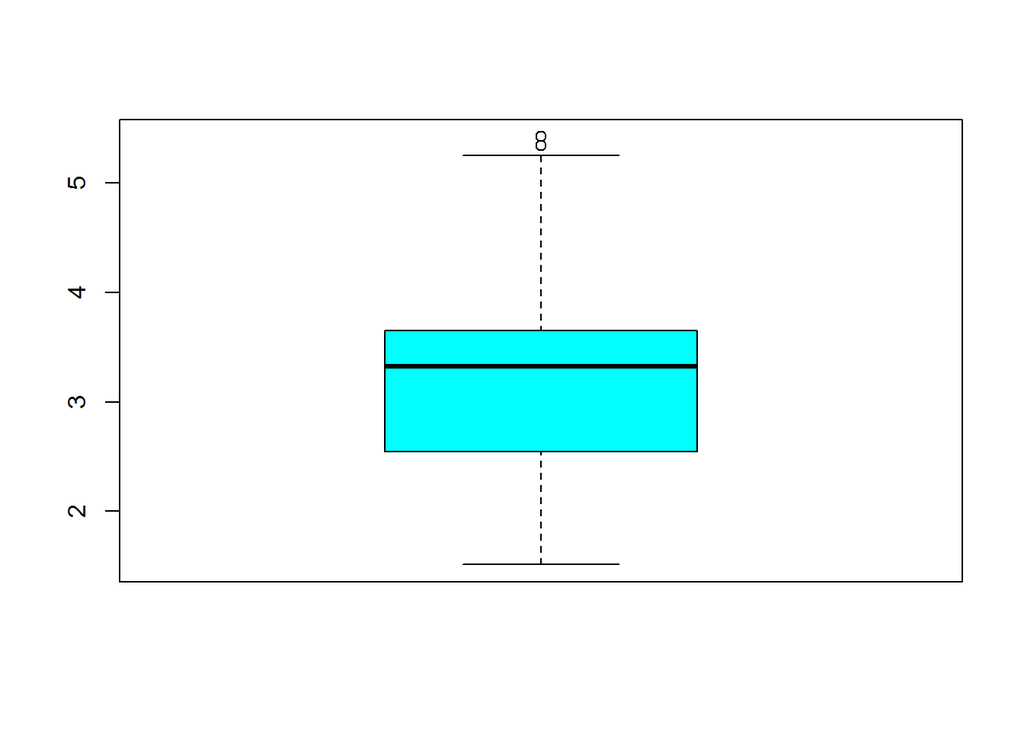

```r
>
> # box plot for "wt" variable
> boxplot(mtcars$wt, col = "cyan")
```

In our the boxplot for `mpg` variable there are on points outside the box, but in the box plot for `wt` variable there are a few points on the high end. These are called outliers, and it might be worth taking a look at them individually. Boxplots are especially good for examining outliers.

You can see from the boxplot that these points have `wt` greater than 5. We can get these variables using `subset()` function. Those are some heavy cars.

```r
> subset(mtcars, mtcars$wt > 5)
##                      mpg cyl disp  hp drat    wt  qsec vs am gear carb
## Cadillac Fleetwood  10.4   8  472 205 2.93 5.250 17.98  0  0    3    4
## Lincoln Continental 10.4   8  460 215 3.00 5.424 17.82  0  0    3    4
## Chrysler Imperial   14.7   8  440 230 3.23 5.345 17.42  0  0    3    4
```

### Histograms

Histograms show the complete empirical distribution of the data, beyond the five data points shown by the boxplots. A histogram is useful to look at when we want to see more detail on the full distribution of the data. The boxplot is quick and handy, but fundamentally only gives us little information. Here, you can easily check skewwness of the data, symmetry, multi-modality, and other features.

We can use `hist()` function to generate a histogram.

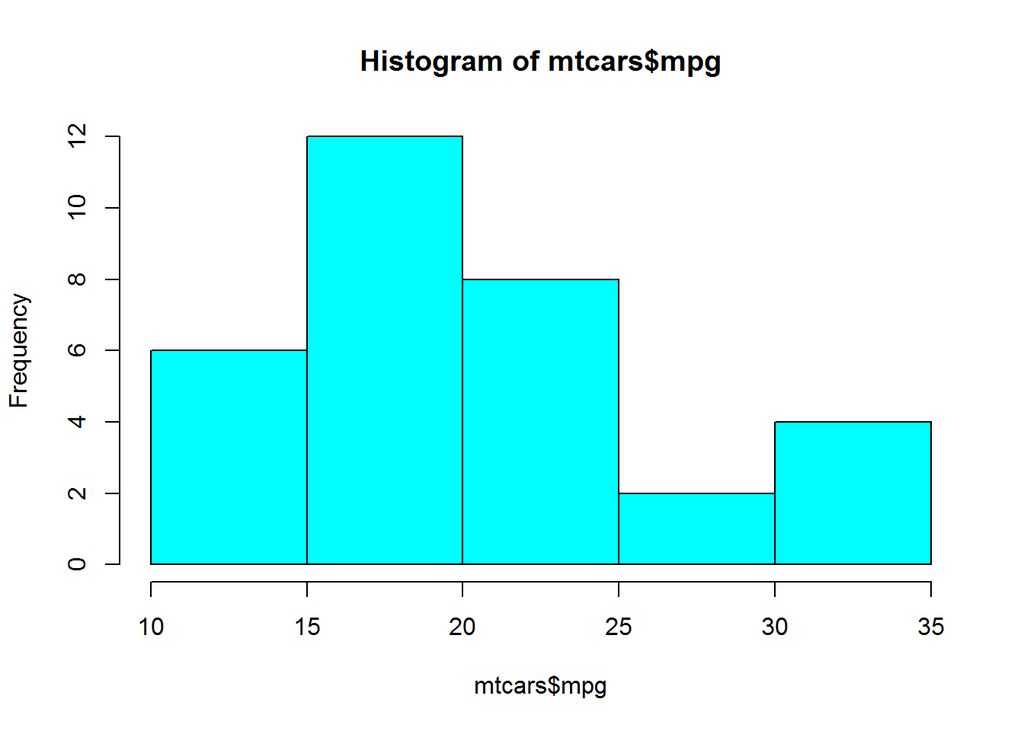

```r
> # histogram of "mpg" variable
> hist(mtcars$mpg, col = "cyan")
```

From this histogram you can see how fuel efficiency of various cars is distributed. A lot of cars have fuel efficiency in between 15 to 20 miles per gallon during 1973-74 period.

The `hist()` function by default determines the number of bars to use in the histogram based on the density of the data. However, you can override the default an argument `breaks`, we can use more bars to try to get more detail. In addition we can get a little more detail of we use the `rug()` function to show us the actual data points.

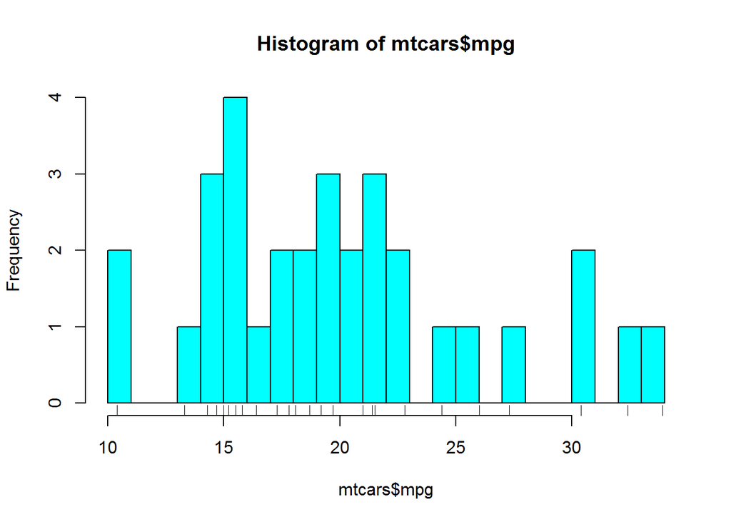

```r
> hist(mtcars$mpg, col = "cyan", breaks = 25)
>
> # shows the actual data points on x axis
> rug(mtcars$mpg)
```

### Barplots

Barplots are useful for visualizing categorical data, with the number of entries for each category being proportional to the height of the bar.

In the `mtcars` dataset all variables are of numeric type. But actually some variables like `am` for example is basically a categorical variable, if `am` is 0 then it means the car has automatic transmission and if its 1 then manual.

The barplot can be made with the `barplot()` function. We use the `table()` function to do the actual tabulation of how many cars have automatc and manula transmission.

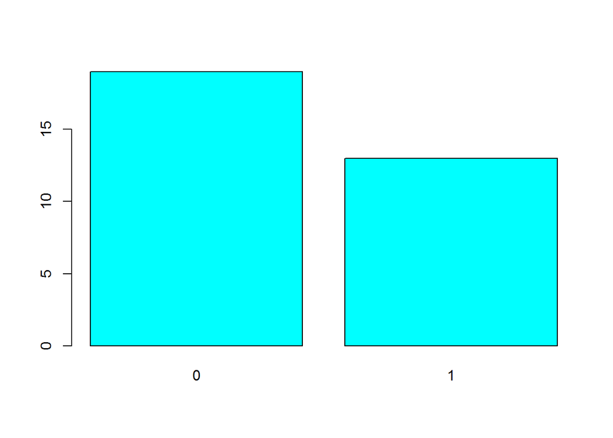

```r
> table(mtcars$am)
##
##  0  1
## 19 13
>
> barplot(table(mtcars$am), col = "cyan")
```

Looking at the barplot we can clearly see that more cars have automatic transmission.

### Density plot

Density plots are usually a much more effective way to view the distribution of a variable. Create the plot using `plot(density(x))` where `x` is a numeric vector.

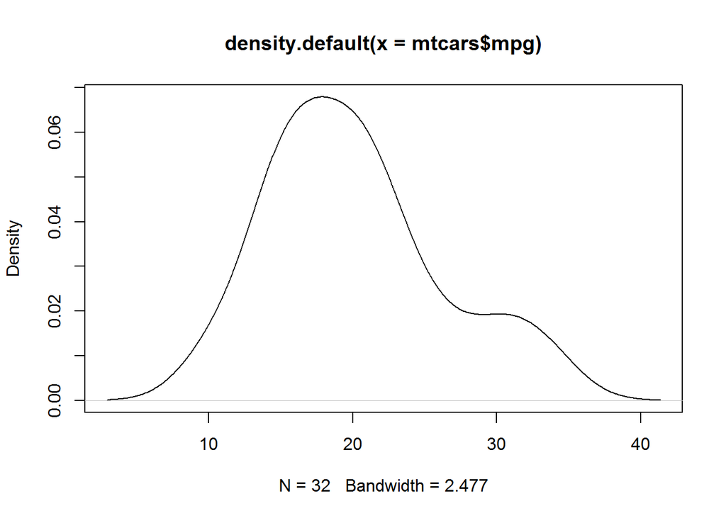

```r
> plot(density(mtcars$mpg))
```

### Dot plot

A dot plot is a statistical chart consisting of all data points plotted on a fairly simple scale. You can create dot plots with the `dotchart()` function.

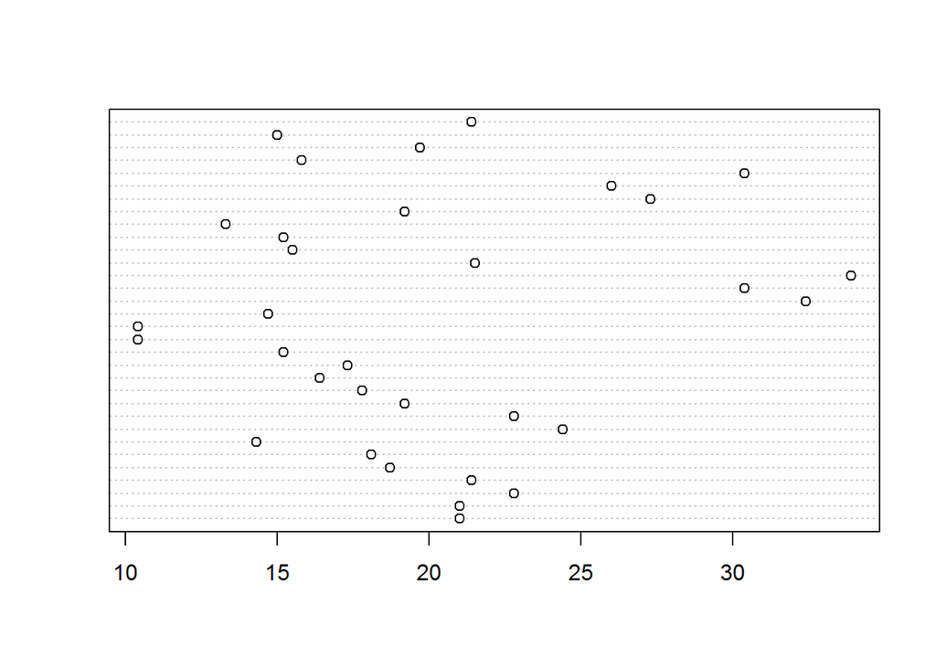

```r
> dotchart(mtcars$mpg)
```

You can give lables to each point using `labels` argument and `cex` argument determines the character size of labels to be used.

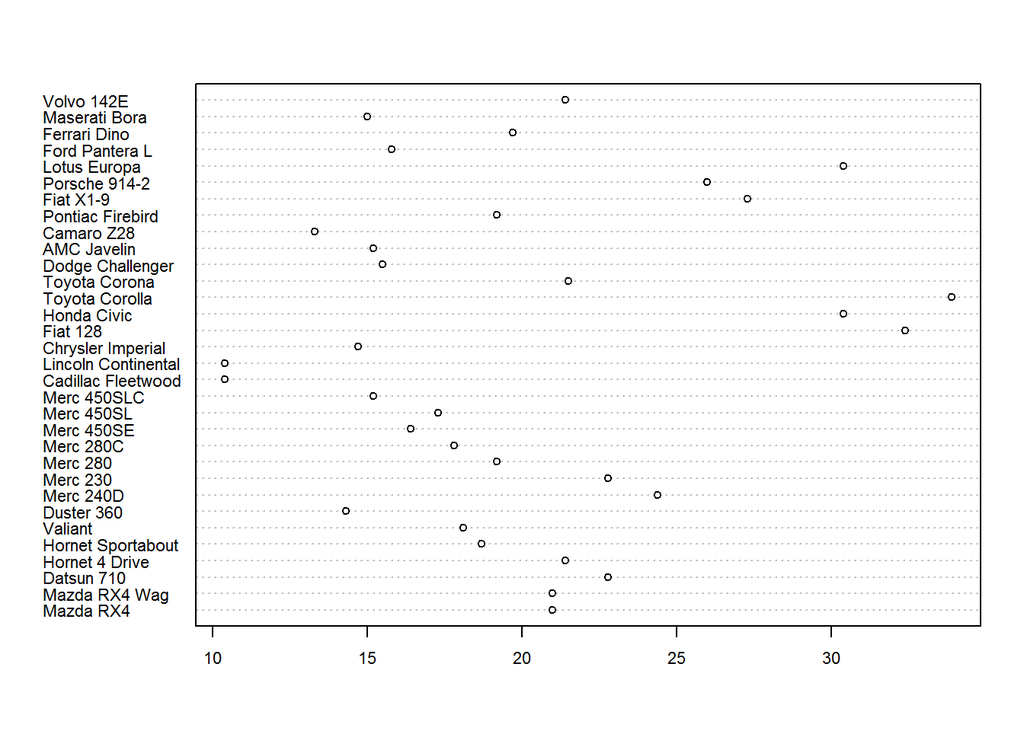

```r
> dotchart(mtcars$mpg, labels = row.names(mtcars), cex=.7)
```

## Simple Two Dimention plots

So far we covered plotting tools for summarizing one dimentional data. Now we will see how we can investigate data in two dimentions. Some of the key approches are

- Overlayed 1-D plots: using multiple boxplots and histograms to visualize one continuous and one categorical variable
- Scatterplots: a natural plot for visualizing two continuous variables
- Using color, size and shape to add dimentions: plotting points with different colors or shapes is useful for indicating a third dimension, where different colors can indicate different categories or ranges of something.
- Smooth scatterplots:a variant of the usual scatterplot function which is useful in cases where there are too many points in the plot to be able to accurately represent each one. Its basically a 2-D histogram.

### Multiple Boxplots

One of the simplest ways to show the relationship between two variables, when one variable is categorical and another one continusous is to show a side by side box plots.

Lets take `mtcars$mpg` and `mtcars$am`, one categorical and one continuous variable. By drawing a boxplot we can show the difference in `mpg` when the car is automatic transmitted(`am = 0`) or manual transmitted(`am = 1`).

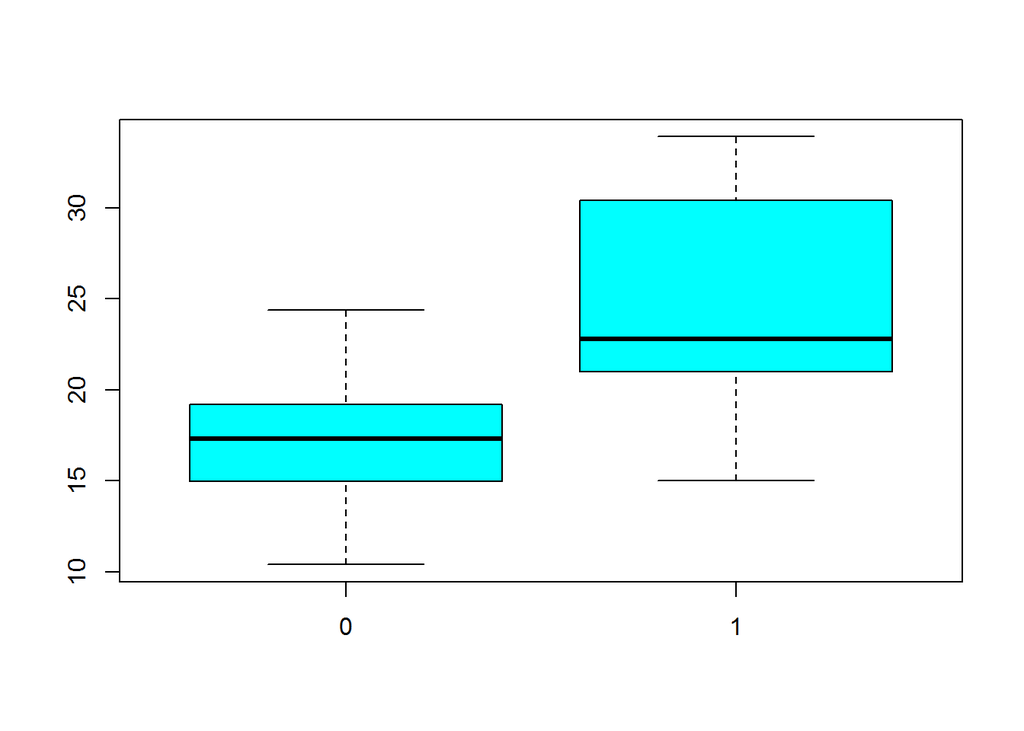

```r
>  boxplot(mpg ~ am, data = mtcars, col = "cyan")
```

Side-by-side boxplots are useful because you can often fit many boxplots on a page to get a rich sense of any trends or changes in a variable accross different categories of another variable. Their compact format allow you to visualize a lot of data in a small space.

### Multiple Histograms

Similar to multiple box plots we can plot multiple histograms to see the changes in shapes of a variable across different categories. Here also we will have one categorical and one continusous variable. However, given histograms occupy more space compared to box plots, the number of histograms that you can effectively put on a page is limited.

There is no direct way to plot multiple histograms like for boxplots. Here is how we can create multiple histograms.

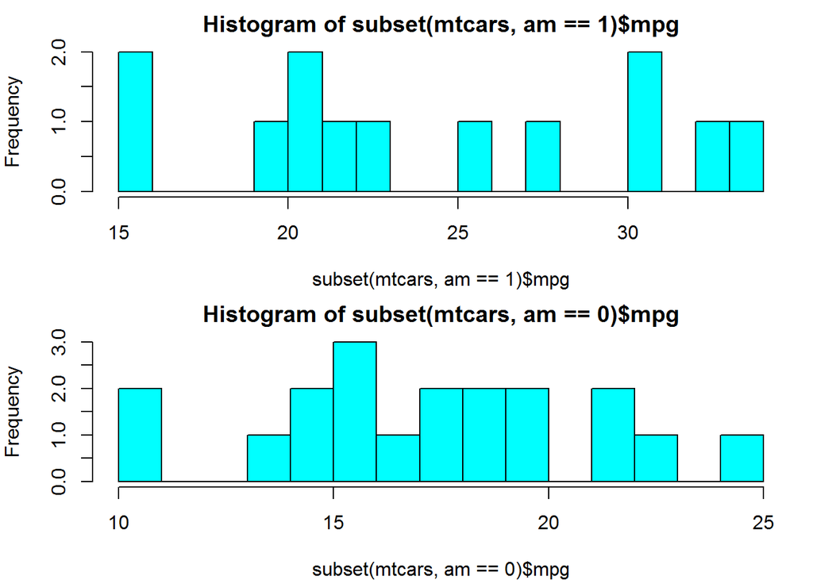

```r
> par(mfrow = c(2,1), mar = c(4,4,2,1))
>
> hist(subset(mtcars, am == 1)$mpg, col = "cyan", breaks = 15)
> hist(subset(mtcars, am == 0)$mpg, col = "cyan", breaks = 15)
```

The `par()` function is basically setting parameters for graphs. The goal of this section is to demonstrate graphs, so i will get get back to the specifics of such functions later. Here we used `subset()` function to subset `mtcars` when `am = 1` and `am = 0`, and immediately indexing using the result with `$` to get `mpg` column.

From the histograms we plotted we dont seem to get much relavant information. But that is all right, the main goal of exploratory data analysis is to look insights in data by plotting graphs. If we dont find any relationships between variables we move onto another variables.

### Scatter plots

For continuous variables the most common visualization is scatter plots. We can visualize 2 continuous variables using scatter plots, which simply maps each variable to an x or y axis coordinate.

Here ia an example of scatter plot made using `plot()` function, on variables `mpg` and `wt`.

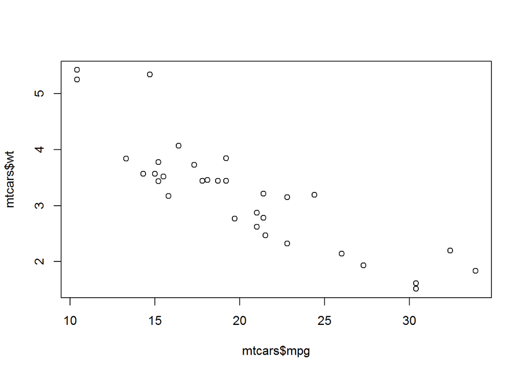

```r
> plot(mtcars$mpg, mtcars$wt)
```

### Using color in scatter plot

If we want to add a third dimension to the scatterplot above we could use color to highlight that dimension.

In the above scatter plot we can color the circles to indicate weather they are automatic transmitted(`am = 0`) or manula transmitted(`am = 1`).

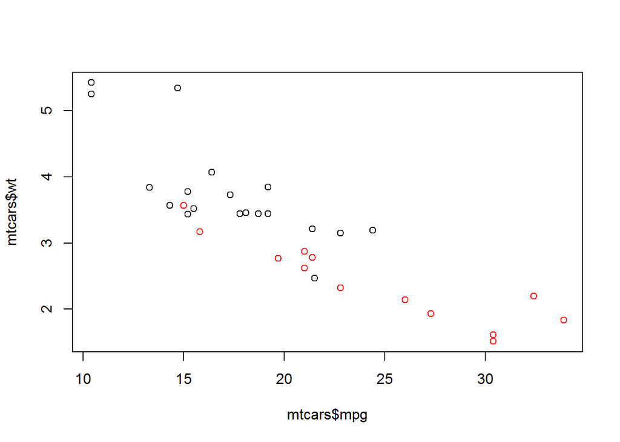

```r
> plot(mtcars$mpg, mtcars$wt, col = ifelse(mtcars$am == 1, "red", "black"))
```

Here `col = ifelse(mtcars$am == 1, "red", "black")` evaluates to “black” if `am = 0` and “red” if `am = 1`. So black points are automatic and red ones are manual transmitted.

This is just an example showing how we can include color as a dimention, in later sections I will explain in detail how we can plot graphs such as this.

### Multiple Scatter plots

Using multiple scatterplots can be necessary when overlaying points with different colors or shapes is confusing. Separating the plots out can sometimes make visualization easier. It is done similat to plotting multiple histograms, using the `par()` and `plot()` functions.

In these 2 plots we can see relation between `mpg` and `wt` when the cars are either automatic(`am = 0`) or manual transmitted(`am = 1`).

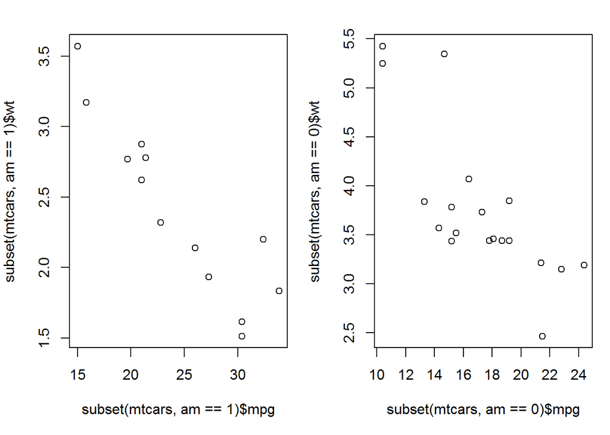

```r
> par(mfrow = c(1, 2), mar = c(5, 4, 2, 1))
>
> plot(subset(mtcars, am == 1)$mpg, subset(mtcars, am == 1)$wt)
>
> plot(subset(mtcars, am == 0)$mpg, subset(mtcars, am == 0)$wt)
```

### Smooth scatterplots

The smooth scatterplots are a variant of scatterplots which are useful in cases where there are too many points in the plot to be able to accurately represent each one. Smooth scatterplots are basically 2 dimentional histograms, these plots will visualize the distribution of data points similar to histograms.

We use `smoothScatter()` to make smooth scatterplots. Since we dont have too many points in `mtcars` dataset smooth scatterplots doesnt help all that much. But when we have lot of points usually smooth scatterplots are preffered.

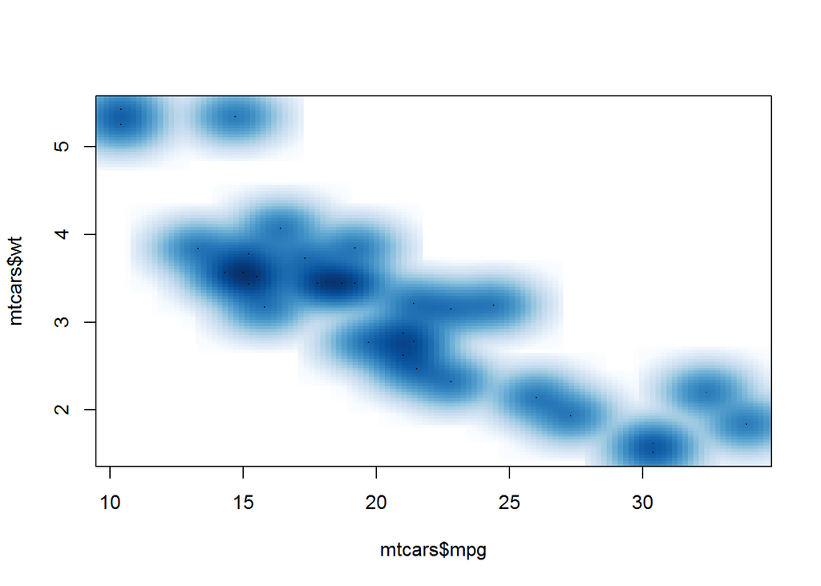

```r
> smoothScatter(mtcars$mpg, mtcars$wt)
```

## Plotting Systems

Now that we are done with looking at different types of plots useful in exploratory data analysis, lets look at several ways how these plots can be plotted using R.

There are three different plotting systems in R and they each have different characteristics and modes of operation. They are

- base plotting system
- lattice system
- ggplot2 system

In the following sections we will discuss each plotting system in detail.

## Base Plotting System

The base plotting system is the original plotting system for R. All the functions we used in the last section such as `boxplot()`, `plot()`, `hist()` etc are from base plotting system. In the previous section we have seen how to draw using vaious types of plots using base plotting system in much more detail.

The base plotting system is often the most convenient plotting system to use because it mirrors how we sometimes think of building plots and analyzing data. If we don’t have a completely well-formed idea of how we want to visualize some data, often we’ll start by just making a simple plot and then slowly add more information to it as our thought process evolves.

The basic model is sometimes referred to as the “artist’s palette” model. The idea is you start with blank canvas and build up from there. There are two phases to creating a base plot: Drawing the plot, and then annotating it. We used functions like `boxplot()`, `barplot()`, `hist()`, `dotchart()`, `plot()`, `smoothScatter()`. Using these functions is usually the first step when using base plotting system for visualizing data. I wont go trough those functions again, you can refer the previsous section After this step we annotate the plot with several more useful details to the plots. We will look at several options to annotate in the following sections.

### Plotting Parameters

All the base plotting functions we saw till now have a set of useful parameters which we can use to make our plots more detailed. Some of such important parameters include

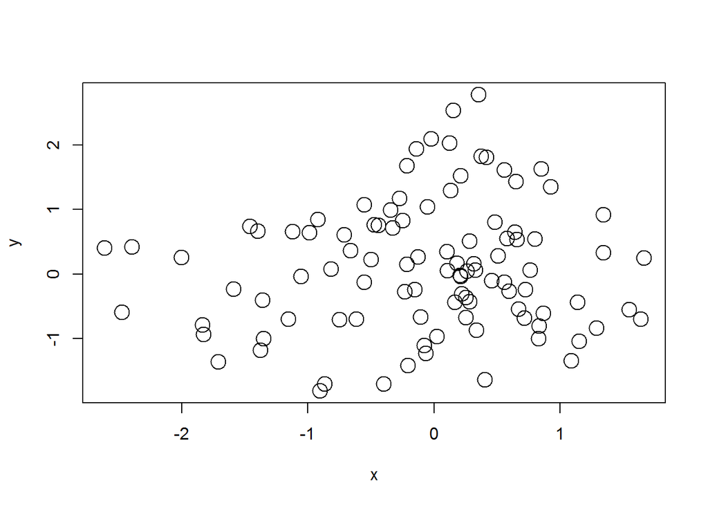

```r
> # pch demo
> x = rnorm(100)
> y = rnorm(100)
>
> # gives circles by defalult without pch and size is double to the default one as we used cex = 2
> plot(x, y, cex = 2)
```

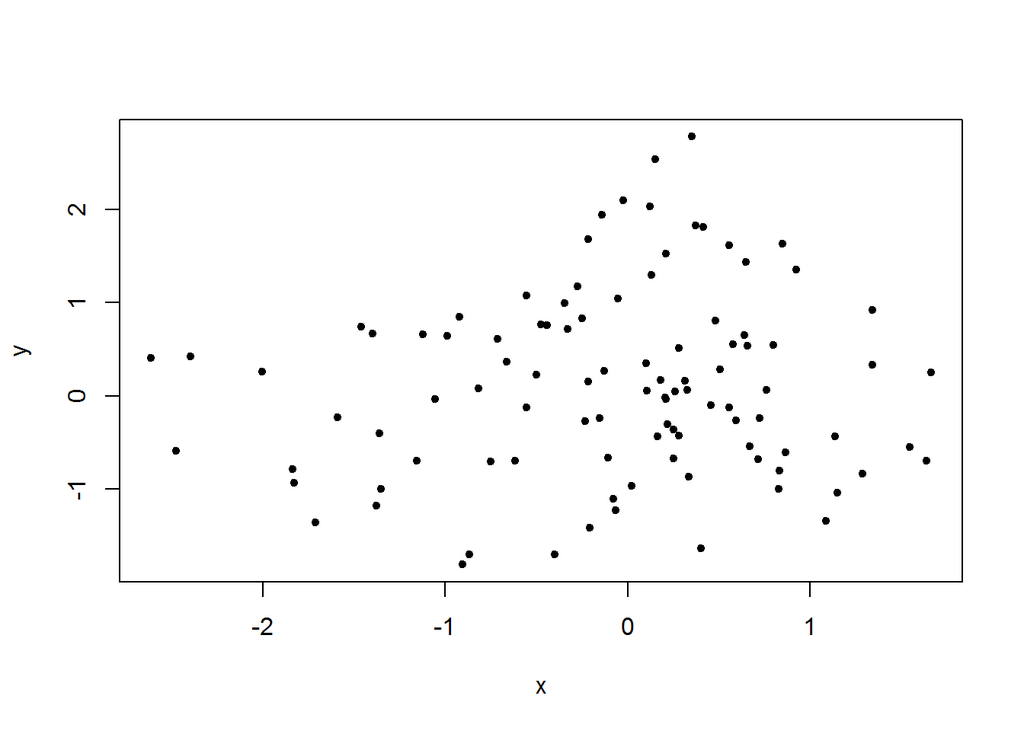

```r
>
> # givis solid points. there are several other options
> plot(x, y, pch = 20)
```

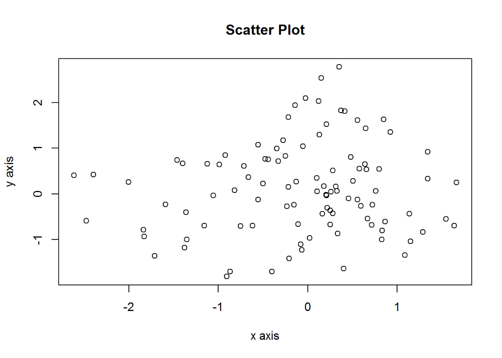

```r
>
> # xlab, ylab, main
> # xlab, ylab and main are assigned by default to the names of variables x, y and type of plot as main hedding. but if you want to customize use these parameters.
> plot(x, y, main = "Scatter Plot", xlab = "x axis", ylab = "y axis")
```

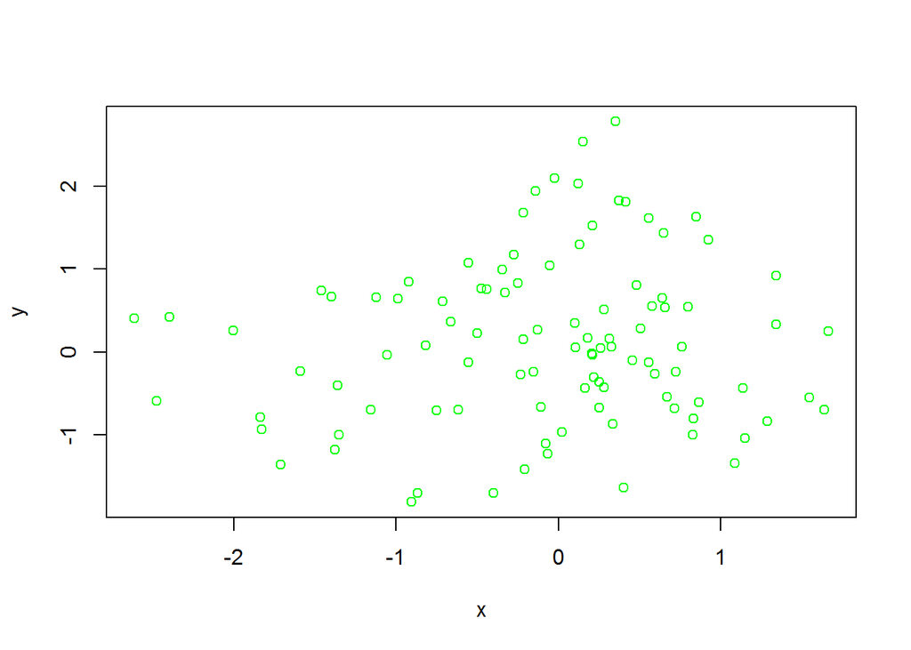

```r
>
> # col is used to change color
> plot(x,y, col = "green")
```

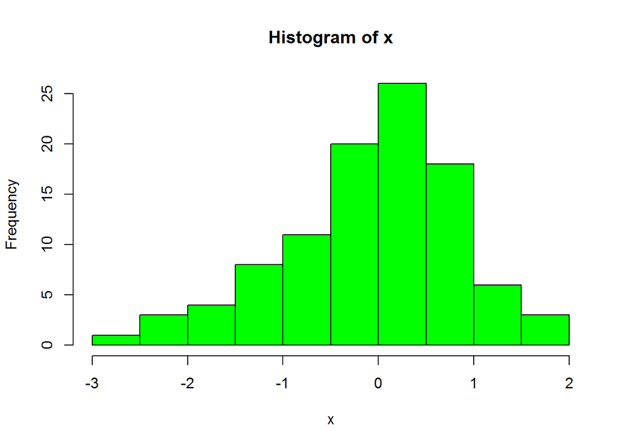

```r
> hist(x, col = "green")
```

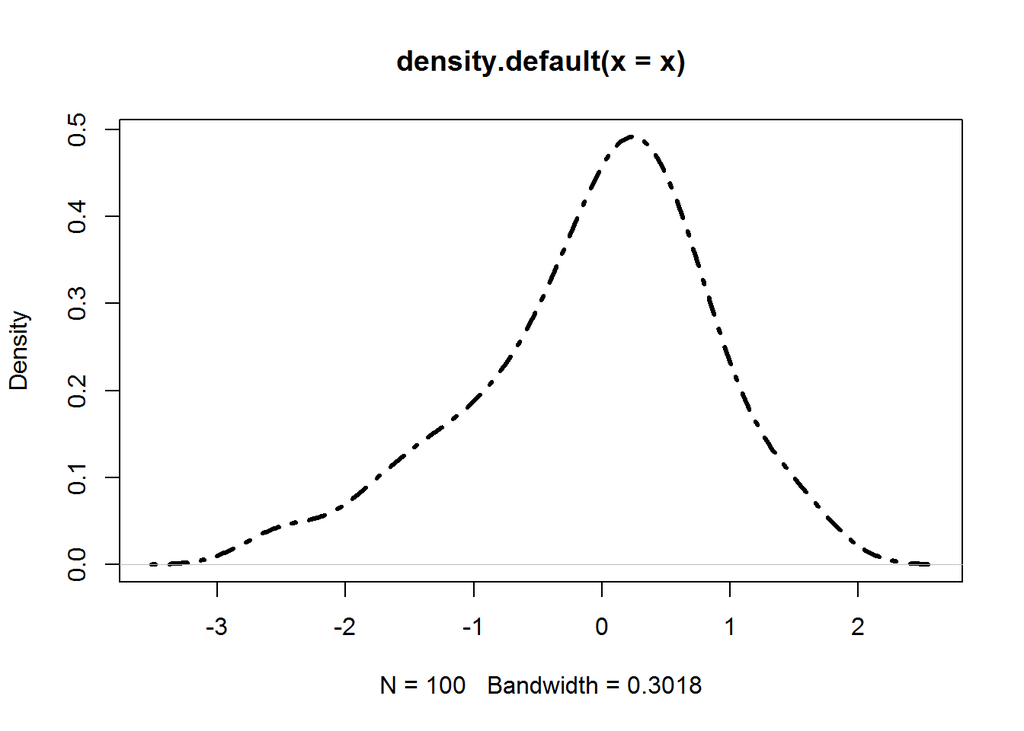

```r
>
> # lty and twd will change line type and width. useful when graphs have lines insterd of points, such as density plot.
> plot(density(x), lty = 4, lwd = 3)
```

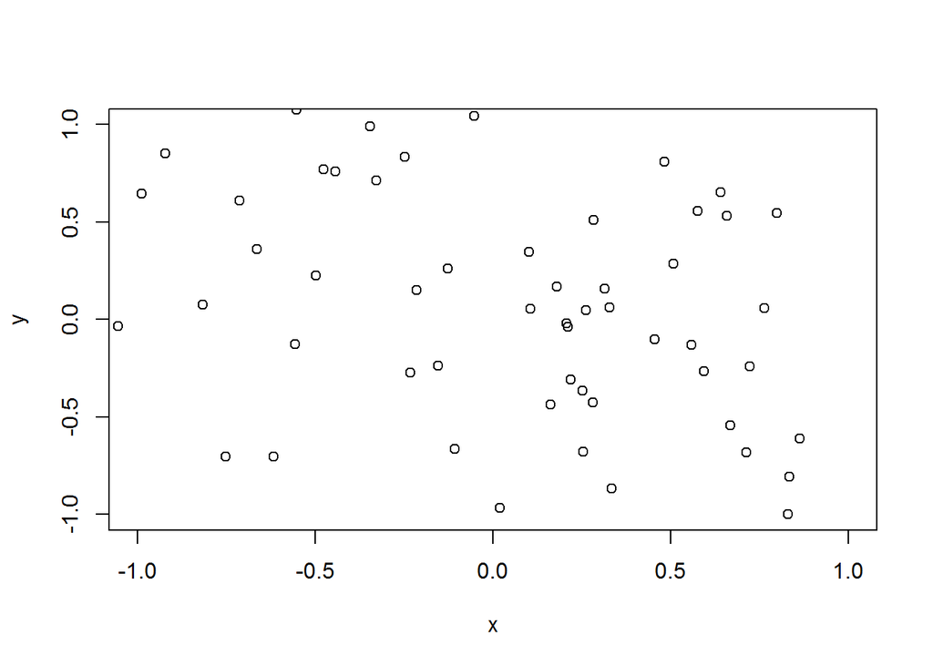

```r
>
> # xlim and ylim basically sets limits for x and y axis
> # as you can see, the x and y axis are in between -1 and 1
> plot(x, y, xlim = c(-1,1), ylim = c(-1,1))
```

One final important parameter is `type`, it is only present in `plot()` function. As the name suggests, it detemines the type of the plot. If you use the `plot()` function without `type` argument it will give points, that is a scatter plot. Suppose if you use `type = "l"` you will get a curve.

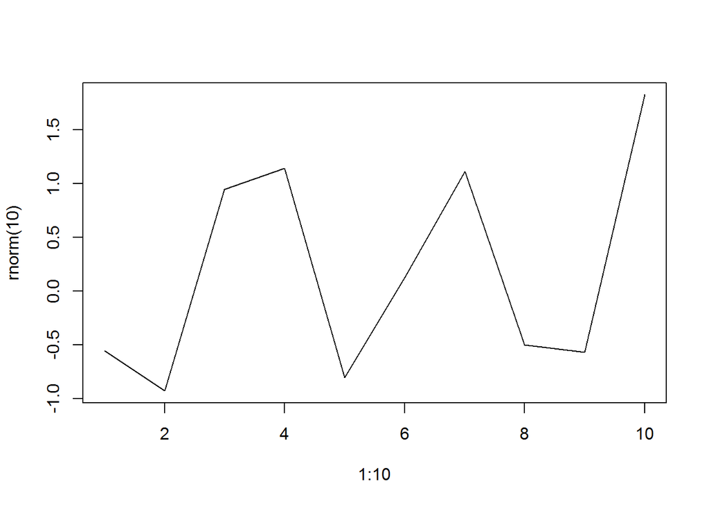

```r
> plot(1:10, rnorm(10), type = "l")
```

### Overlaying Features

Once we start seeing interesting features in our data, it’s often useful to lay down annotations on our plots as reference points. For example consider a boxplot, we might want to draw a horizontal line at an important value.

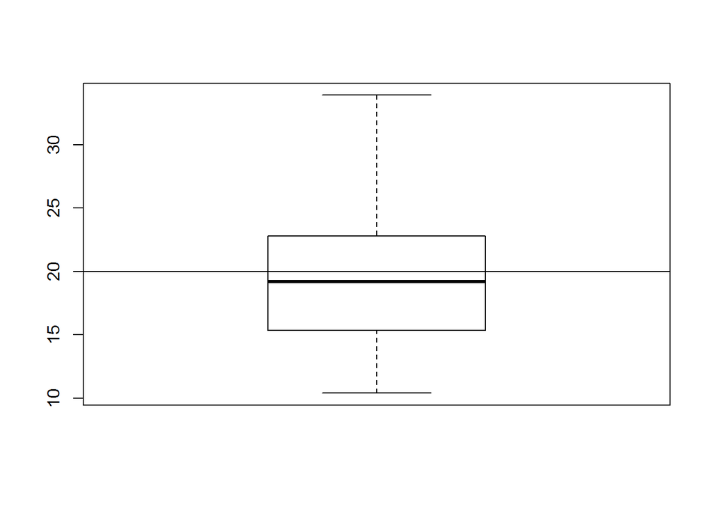

```r
> boxplot(mtcars$mpg)
> abline(h = 20)
```

Similarly for histogram of `mpg` we would need to draw a vertical line. We do that using `v` parameter. You can also use `col`, `lwd` parameters for `abline()` function.

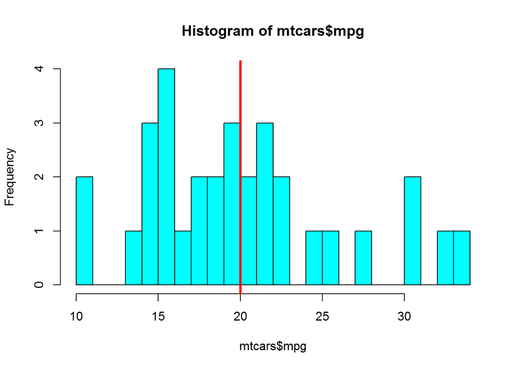

```r
> hist(mtcars$mpg, breaks = 25, col = "cyan")
> abline(v = 20, col = "red", lwd = 3)
```

**Quick Questions**

1. Draw a histogram of `mtcars$wt` with 2 vertical lines at median and mean. Make those 2 lines in different color.